# Diabetes y Tuberculosis en Ciutat Vella (Barcelona). Estudio longitudinal de la asociación de las dos enfermedades en un distrito con alta prevalencia de tuberculosis

Ramó Puig, Elena Navas i Jordi Real

10 marzo, 2020

DRAFT

# Objectivos

## Objetivo principal

- Analizar la relación epidemiológica y los factores asociados entre la DM y la TB en un distrito de elevada prevalencia de TB (Ciutat Vella de Barcelona).
- Conocer el riesgo de TB entre la población con DM en un distrito de elevada prevalencia de TB (Ciutat Vella de Barcelona) para identificar subgrupos de alto riesgo y potencialmente susceptibles de cribado de TB.

## Objetivos secundarios

- 1. Comparar la evolución de la prevalencia de la DM y de la TB en el periodo 2006 al 2015 en el distrito de Ciutat Vella, un entorno de alta prevalencia de TB.
- 2. Conocer la prevalencia y la incidencia de TB entre la población con DM con respecto a la población no diabética.
- 3. Analizar si el grado de control metabólico de la DM influye en la forma de TB (pulmonar o extrapulmonar), la gravedad y la respuesta al tratamiento.
- 4. Analizar el papel de la inmigración en la relación entre DM y TB.

## Actualizaciones

✓ Generació de 251 variables  
✓ Actualització de dades de l’Ecap  
✓ Vinculació de taules E-cap  
✓ Depuració de dades  
✓ Reprogramació i generació de resultats

## Hecho:

✓ Lectura de tablas de históricos de E-Cap proporcionadas por Basic ✓ Agregación en fecha de inclusión (1/2007) ✓ vinculación de tablas en una ✓ Depuración de errores (Eliminación de duplicados, valores negativos …..) ✓ Cálculo de variables ✓ Descriptivo inicial exploratorio ✓ Análisis de associación de DM versus TBC ✓ Estimación de incidéncias

## Pendiente:

- Depurar base de datos (Corregir errores, definir rango de valores válidos etc…)
- Etiquetar variables
- Análisis por objetivos
- Generar cohorte dinámica y/o apareada

## Consideraciones / limitaciones:

- Solo TBC con fecha disponible
- Excluidos repetidos
- Base de datos vacunas solo disponible a partir de 12/2007 (No en basal)
- Reclasificados expuestos diabeticos en fecha de inclusión (1/2007)
- Possible infraregistro de diagnosticos en 2007
- Alto número de valores faltantes

# Método

Cohorte estatica a 01/2007 con seguimiento hasta 31/12/2018

Criterios de inclusión: Pacientes DM y controles de **Ciutat Vella** vinculados con el registro del programa de prevención y control de Tuberculosi de Barcelona.

## Flowchart

[interactive chart not shown]

# Resultats

## Característiques basals

- Descriptiu de característiques basals entre grups

Descriptiva de caracterítiques basals entre grups

|  | Control | DM | p.overall | N |
| --- | --- | --- | --- | --- |
|  | N=26223 | N=5870 |  |  |
| sexe: |  |  | <0.001 | 32093 |
| D | 11123 (42.4%) | 2883 (49.1%) |  |  |
| H | 15100 (57.6%) | 2987 (50.9%) |  |  |
| Edat (anys) | 40.0 (18.2) | 56.6 (27.5) | 0.000 | 32093 |
| Anys evolució de DM | . (.) | 6.96 (7.52) | . | 5870 |
| Colesterol HDL | 56.4 (15.7) | 52.3 (15.5) | <0.001 | 4015 |
| Colesterol LDL | 132 (36.2) | 117 (33.1) | <0.001 | 3910 |
| Colesterol total | 210 (42.2) | 198 (42.1) | <0.001 | 4935 |
| Glicèmia | 6.88 (2.65) | 9.00 (.) | . | 6 |
| HBA1C | 5.71 (1.52) | 6.99 (1.67) | <0.001 | 2585 |
| Hemoglobina | 13.4 (1.39) | 13.0 (1.33) | <0.001 | 1089 |
| Leucòcits | 14.7 (12.7) | 12.8 (6.16) | 0.334 | 117 |
| Plaquetes | 244 (75.9) | 242 (74.5) | 0.815 | 251 |
| Triglicèrids | 94.6 (28.3) | 101 (27.5) | <0.001 | 2731 |
| VSG | 15.1 (12.1) | 22.6 (18.7) | <0.001 | 725 |
| IMC | 27.5 (5.80) | 29.4 (5.00) | <0.001 | 3778 |
| Pressió arterial diastòlica | 78.3 (11.7) | 76.9 (11.0) | <0.001 | 7459 |
| Pressió arterial sistòlica | 132 (18.1) | 139 (18.7) | <0.001 | 7437 |
| Pes kg | 73.7 (17.4) | 75.7 (14.6) | <0.001 | 5099 |
| Talla cm | 162 (12.0) | 160 (9.71) | <0.001 | 4011 |
| P_G_60.valor: Si | 1952 (7.44%) | 2704 (46.1%) | 0.000 | 32093 |
| P_G_AD.valor: Si | 779 (2.97%) | 527 (8.98%) | <0.001 | 32093 |
| P_G_AR.valor: Si | 163 (0.62%) | 183 (3.12%) | <0.001 | 32093 |
| P_G_NE.valor: Si | 219 (0.84%) | 448 (7.63%) | <0.001 | 32093 |
| Visites MG | 41.4 (42.1) | 63.2 (54.8) | <0.001 | 26338 |
| Visites totals | 75.9 (69.9) | 109 (86.2) | <0.001 | 25559 |
| FP.ADO: Si | 98 (0.37%) | 1967 (33.5%) | 0.000 | 32093 |
| FP.CORTIS: Si | 68 (0.26%) | 55 (0.94%) | <0.001 | 32093 |
| FP.IMMU: Si | 24 (0.09%) | 14 (0.24%) | 0.006 | 32093 |
| FP.ADO_ALT: Si | 2 (0.01%) | 111 (1.89%) | <0.001 | 32093 |
| FP.ADO_MET: Si | 65 (0.25%) | 1372 (23.4%) | 0.000 | 32093 |
| FP.ADO_SU: Si | 50 (0.19%) | 1006 (17.1%) | 0.000 | 32093 |
| FP.INSU: Si | 18 (0.07%) | 474 (8.07%) | 0.000 | 32093 |
| DG.ALCOHOL_cat: Yes | 688 (2.62%) | 235 (4.00%) | <0.001 | 32093 |
| DG.ARTPER_cat: Yes | 93 (0.35%) | 228 (3.88%) | <0.001 | 32093 |
| DG.ARTREUMA_cat: Yes | 41 (0.16%) | 26 (0.44%) | <0.001 | 32093 |
| DG.AVC_cat: Yes | 183 (0.70%) | 438 (7.46%) | <0.001 | 32093 |
| DG.BEHCET_cat: Yes | 4 (0.02%) | 2 (0.03%) | 0.303 | 32093 |
| DG.CARD_ISQU_cat: Yes | 344 (1.31%) | 660 (11.2%) | 0.000 | 32093 |
| DG.CLAMIDIA_cat: Yes | 10 (0.04%) | 2 (0.03%) | 1.000 | 32093 |
| DG.DM1_cat: Yes | 0 (0.00%) | 298 (5.08%) | <0.001 | 32093 |
| DG.DM2_cat: Yes | 0 (0.00%) | 5645 (96.2%) | 0.000 | 32093 |
| DG.DME13_cat: Yes | 0 (0.00%) | 35 (0.60%) | <0.001 | 32093 |
| DG.ESCLERODER_cat: Yes | 4 (0.02%) | 1 (0.02%) | 1.000 | 32093 |
| DG.GONOCOCIA_cat: Yes | 9 (0.03%) | 0 (0.00%) | 0.380 | 32093 |
| DG.INSU_CARD_cat: Yes | 78 (0.30%) | 265 (4.51%) | <0.001 | 32093 |
| DG.INSU_RENA_cat: Yes | 60 (0.23%) | 245 (4.17%) | <0.001 | 32093 |
| DG.LUPUS_cat: Yes | 7 (0.03%) | 4 (0.07%) | 0.125 | 32093 |
| DG.PNEUMO_cat: Yes | 126 (0.48%) | 80 (1.36%) | <0.001 | 32093 |
| DG.POLIARTRI_cat: Yes | 10 (0.04%) | 6 (0.10%) | 0.096 | 32093 |
| DG.SARCOID_cat: Yes | 5 (0.02%) | 5 (0.09%) | 0.023 | 32093 |
| DG.SIDA_cat: Yes | 440 (1.68%) | 39 (0.66%) | <0.001 | 32093 |
| DG.SIFILIS_cat: Yes | 69 (0.26%) | 14 (0.24%) | 0.846 | 32093 |
| DG.SJOGREN_cat: Yes | 29 (0.11%) | 19 (0.32%) | <0.001 | 32093 |
| DG.TRANS_REN_cat: Yes | 3 (0.01%) | 7 (0.12%) | <0.001 | 32093 |
| DG.VASCULITIS_cat: Yes | 0 (0.00%) | 6 (0.10%) | <0.001 | 32093 |
| DG.AUTOIM_cat: Yes | 99 (0.38%) | 65 (1.11%) | <0.001 | 32093 |
| DG.DM_NEFRO_cat: Yes | 0 (0.00%) | 116 (1.98%) | <0.001 | 32093 |
| DG.DM_NEURO_cat: Yes | 0 (0.00%) | 132 (2.25%) | <0.001 | 32093 |
| DG.DM_OFTALMO_cat: Yes | 0 (0.00%) | 409 (6.97%) | 0.000 | 32093 |
| DG.ITS_cat: Yes | 88 (0.34%) | 16 (0.27%) | 0.522 | 32093 |

| descNacionalitat | n |
| --- | --- |
| AFGANISTAN | 13 |
| ALBÀNIA | 8 |
| ALEMANYA | 216 |
| ALGÈRIA | 123 |
| ANDORRA | 2 |
| ANGOLA | 1 |
| ARÀBIA SAUDITA | 3 |
| ARGENTINA | 179 |
| ARMÈNIA | 23 |
| AUSTRÀLIA | 10 |
| ÀUSTRIA | 18 |
| AZERBAIDJAN | 2 |
| BANGLA DESH | 701 |
| BÈLGICA | 42 |
| BERMUDES | 1 |
| BHUTAN | 1 |
| BIELORÚSSIA | 9 |
| BOLÍVIA | 127 |
| BRASIL | 101 |
| BULGÀRIA | 42 |
| BURKINA FASO | 1 |
| CAMERUN | 5 |
| CANADÀ | 19 |
| COLòMBIA | 96 |
| CONGO | 1 |
| COREA, REPÚBLICA DE | 9 |
| COREA, REPÚBLICA DEMOCRÀTICA POPULAR DE | 1 |
| COSTA RICA | 5 |
| CROÀCIA | 3 |
| CUBA | 39 |

[output cut: 96 more lines]

## Incidència de TBC

Resum d’events

| Patients | PYears | temps_seguiment | N.Events | Event.rate | IA |
| --- | --- | --- | --- | --- | --- |
| 32093 | 334404.8 | 10.41987 | 185 | 0.0553222 | 0.0057645 |

Resum d’events per exposició a diabetis

| grup | Patients | PYears | temps_seguiment | N.Events | Event.rate | IA |
| --- | --- | --- | --- | --- | --- | --- |
| Control | 26223 | 275585.37 | 10.50930 | 157 | 0.0569696 | 0.0059871 |
| DM | 5870 | 58819.43 | 10.02035 | 28 | 0.0476033 | 0.0047700 |

Incidència i Hazard Ratio de Tuberculosis

|  | No event | Event | HR | p.ratio | p.overall |
| --- | --- | --- | --- | --- | --- |
|  | N=31908 | N=185 |  |  |  |
| grup: |  |  |  |  | 0.349 |
| Control | 26066 (99.4%) | 157 (0.60%) | Ref. | Ref. |  |
| DM | 5842 (99.5%) | 28 (0.48%) | 0.83 [0.55;1.23] | 0.350 |  |

## HR ajustats

HR ajustats segons covariables

|  | N | EVENTS | HRadjusted | IC951 | IC952 | p |
| --- | --- | --- | --- | --- | --- | --- |
| grupDM | 32093 | 185 | 0.827 | 0.541 | 1.264 | 0.379 |
| sexeH | 32093 | 185 | 2.402 | 1.713 | 3.369 | 0.000 |
| age | 32093 | 185 | 1.003 | 0.995 | 1.011 | 0.464 |

## Supervivencia K-M

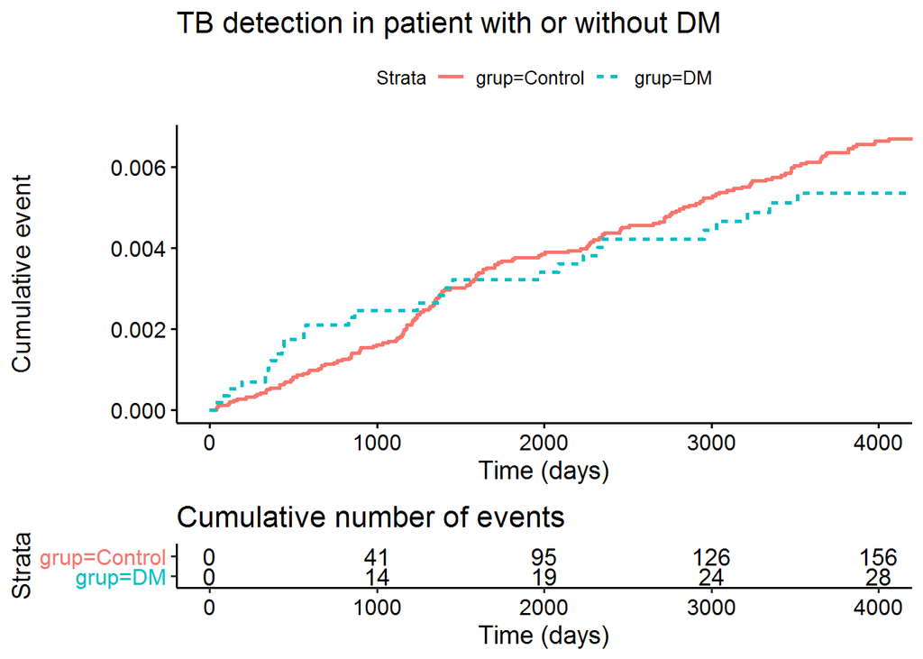

A work by $Jordi Real$

$Llepali-System$

*https://github.com/USR-DAPCAT/*